# homework

```python
import pandas as pd

df = pd.read_csv("heritage_sites.csv")


df.head()
```

|  | Heritage Site | City / Location | Country | Region | Category | Year of Inscription | Criteria | Area (ha) | Historical Period |
| --- | --- | --- | --- | --- | --- | --- | --- | --- | --- |
| 0 | Acropolis, Athens | Athens | Greece | Southern Europe | Cultural | 1987 | (i)(ii)(iii)(iv)(vi) | 3.04 | Ancient |
| 1 | Historic Centre of Prague | Prague | Czechia | Central Europe | Cultural | 1992 | (ii)(iv)(vi) | 1106.36 | Medieval–Modern |
| 2 | La Grand-Place, Brussels | Brussels | Belgium | Western Europe | Cultural | 1998 | (ii)(iv) | 1.48 | Medieval–Baroque |
| 3 | Flemish Béguinages | Flanders | Belgium | Western Europe | Cultural | 1998 | (ii)(iii)(iv) | 61.14 | Medieval |
| 4 | Historic Centre of Brugge | Bruges | Belgium | Western Europe | Cultural | 2000 | (ii)(iv)(vi) | 410.00 | Medieval |

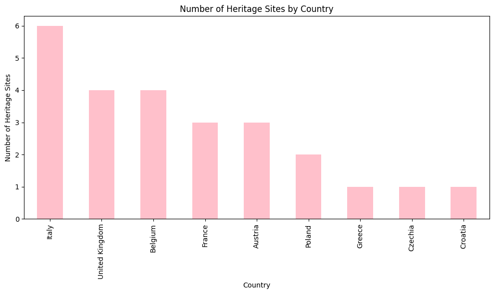

```python
# Count the number of heritage sites in each country
country_counts = df["Country"].value_counts()

# bar chart
plt.figure(figsize=(10, 6))
country_counts.plot(kind="bar", color="#FFC0CB")

plt.title("Number of Heritage Sites by Country")
plt.xlabel("Country")
plt.ylabel("Number of Heritage Sites")
plt.tight_layout()

plt.show()
```

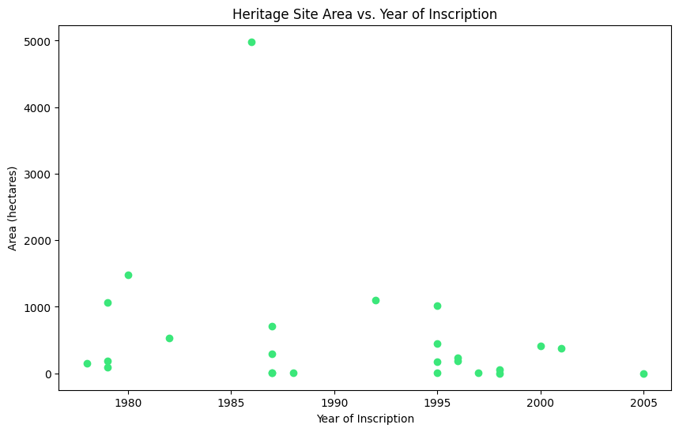

```python
# Convert the columns to numbers
df["Year of Inscription"] = pd.to_numeric(df["Year of Inscription"])
df["Area (ha)"] = pd.to_numeric(df["Area (ha)"])

# scatter plot
plt.figure(figsize=(10, 6))

plt.scatter(df["Year of Inscription"], df["Area (ha)"], color="#3BE77A")

plt.title("Heritage Site Area vs. Year of Inscription")
plt.xlabel("Year of Inscription")
plt.ylabel("Area (hectares)")

plt.show()
```

The scatter plot does not show a clear relationship between the year a site was inscribed and its area. Large and small heritage sites were added to the World Heritage List throughout the different years. There are several particularly large sites, but they do not appear to be concentrated in one specific period.

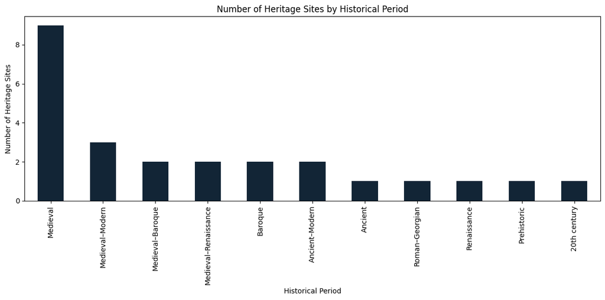

```python
# Count the number of sites for each historical period
period_counts = df["Historical Period"].value_counts()

# bar chart
plt.figure(figsize=(12, 6))
period_counts.plot(kind="bar", color="#122536")

plt.title("Number of Heritage Sites by Historical Period")
plt.xlabel("Historical Period")
plt.ylabel("Number of Heritage Sites")

plt.tight_layout()
plt.show()
```

Medieval sites are the most common historical period in this dataset. Several sites also combine multiple periods, such as Medieval–Modern or Medieval–Renaissance. This suggests that many of the heritage sites represent long periods of historical development rather than belonging to only one specific period.